# Stochastic Processes

Supplemental code for lecture 3, U20 Math 585

Sami Cheong

9/29/2020

### Visualizing discrete-time Markov chains using the `markovchain` package

In this example, we’ll look at how to visualize the graphical representation of a Markov chain (i.e. in the form of a *weighted directed graph*). Fortunately, there is a package `markovchain` written specifically to handle these kind of tasks, limited to discrete time Markov chain (DTMC). Let’s take a look at a simple example here:

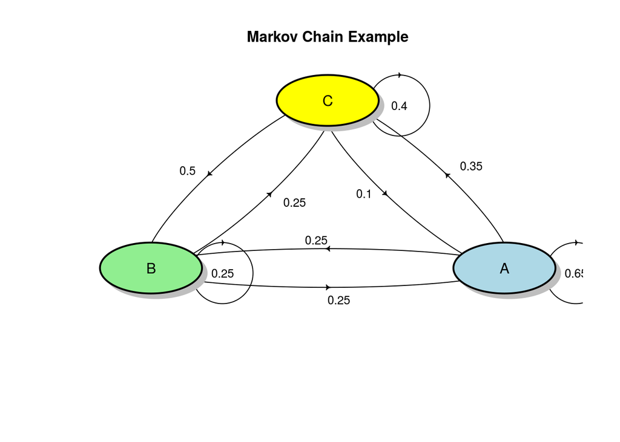

```r
# define a transition matrix (row sum needs to be 1)
mc <- matrix(c(0.65,0.25,0.1,
               .25,0.25,.5,
               .35,.25,0.4),nrow = 3, byrow = TRUE)
# define state names
stateNames <- c("A","B","C")

# populate column and row names
row.names(mc) <- stateNames;

colnames(mc) <- stateNames

mc.obj <- new("markovchain",transitionMatrix=mc, states=c("A","B","C"), name="mc")
#plotmat(mc)
# visualize the transition matrix using plotmat (a function from the package 'diagram')
plotmat(mc,
        lwd = 1, box.lwd = 2,
        cex.txt = 0.8,
        box.size = 0.1,
        box.type = "circle",
        box.prop = 0.5,
        box.col = c("light blue","light green","yellow"),
        arr.length=.1,
        arr.width=.1,
        self.cex = .6,
        self.shifty = -.01,
        self.shiftx = .14,
        main = "Markov Chain Example")
```

### n-step transition matrix:

```r
# where we are at the initial state:
s0<-c(1,0,0)
# how many steps to take:
steps <- 10
# sovle for sn:
sn <-s0*mc^steps #using power operator

sn
```

```
##            A            B     C
## A 0.01346274 9.536743e-07 1e-10
## B 0.00000000 0.000000e+00 0e+00
## C 0.00000000 0.000000e+00 0e+00
```

### Calculating joint distribution of a Markov chain

**R Pre-requisites**:

- *Multiplication of matrices* uses the command `%*%` as opposed to `*` which is just element-wise multiplication
- *Power of matrices* uses the command `%^%` after installing the library `expm`

In the following example we’ll take a look at how to generate joint distribution for a given Markov chain with finite state space, and initial distribution. Consider Danny’s daily lunch choices, which is modeled as a Markov chain with 4 states $S = \{ \text{Burrito, Falafel, Pizza, Sushi}\} = \{b,f,p,s\}$ with the transition matrix:
$$\begin{bmatrix} 0 & 0.5 & 0.5 &0 \\ 0.5& 0 &0.5 &0\\ 0.4 &0&0 &0.6 \\ 0 &0.2&0.6 & 0.2\end{bmatrix}$$

Suppose on Sunday, Danny chooses lunch uniformly at random. Find the probability that he chooses sushi on the following Wednesday and Friday, and pizza on Saturday.

```r
# load the matrix exponents package
library(expm)

#initial distribution (each choice is equally likely)

alpha <-matrix(rep(0.25,1),nrow = 1, ncol = 4)

# 1-step transition matrix
P <- matrix(rbind(c(0,0.5,0.5,0),c(0.5,0,0.5,0),c(0.4,0,0,0.6),c(0,0.2,0.6,0.2)), nrow = 4, ncol = 4)
P2 <- P%^%2
P3 <- P%^%3

p_ssp <- alpha%*%P3[,4]*P2[4,4]*P[4,3]

print(paste0("The answer is :", p_ssp))
```

```
## [1] "The answer is :0.05952"
```

### Long-term behavior of a Markov chain : some numerical evidence

In here, we ask the question of whether a given transition matrix $P$, when taken to the $n^{th}$ power, would converge to something stationary if we let $n\to\infty$? Let’s take a look using the same example above:

```r
N <-c(10,20,30,40)

Pn <-list()

i <-1
for (n in N){

  Pn[[i]] <-P%^%n
  i <-i+1


}
```

We can also visualize the matrices:

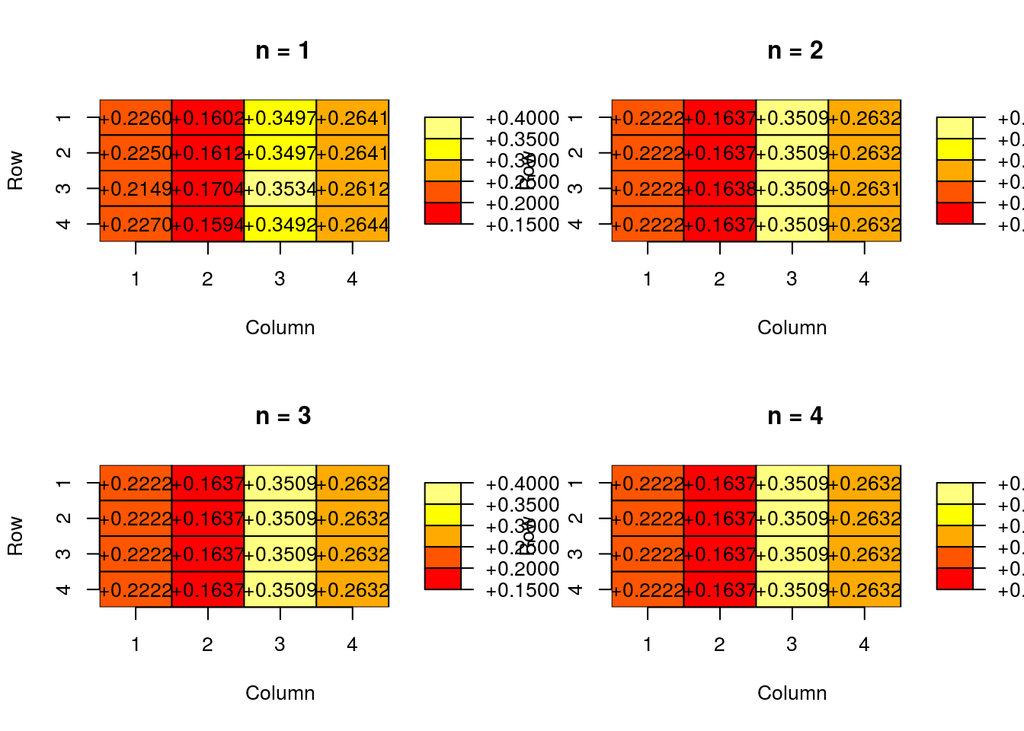

```r
library('plot.matrix')

par(mfrow = c(2,2))

for (i in 1:4){
  plot(Pn[[i]],digits = 4,main = paste(' n =', i))
}
```

### Simulating Markov chain : Lung cancer study example

Medical researchers have used many tools to study the progression of lung cancer in the body, one of these tools is simulation. The dataset `lungcancer` denotes the presence or absence of lung cancer growth in different parts of the body, which is described as a 50-site numbering system. (Source of data: “A stochastic Markov chain model to describe lung cancer growth and metastatis” by Newton, et al. PLoS ONE, Volume 7, Issue 4, April 2012, pp 1-18.)

Below is a visual representation of the transition matrix in the study by Newton et al. In here, the state space $\mathbf{S}$ is the set of organs classified by the 50-site numbering system, and therefore the transition matrix is a $50 \times 50$ matrix

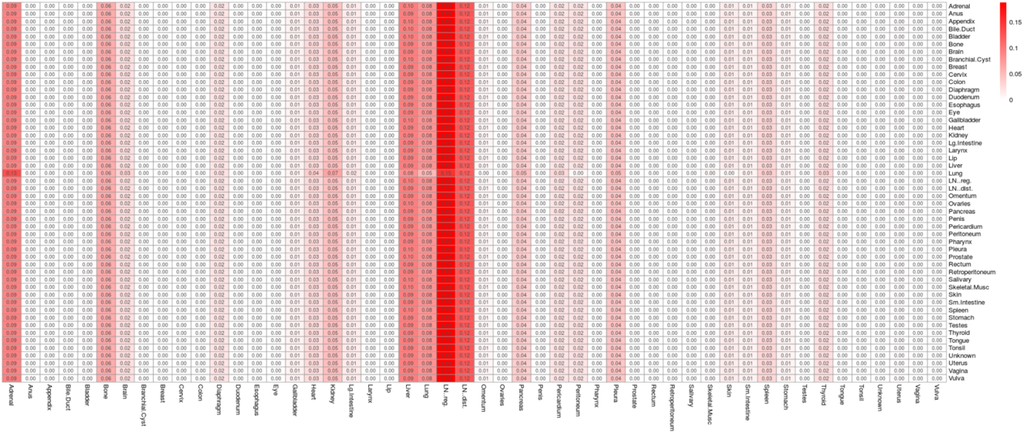

Transition matrix of lung cancer progression

```r
library(ggplot2)
library(knitr)
library(markovchain)
#library(pheatmap)

include_graphics('datasets/cancer_mc.png')
```

```r
mat <-read.csv('datasets/lungcancer.csv',header = TRUE)
```

Suppose we are interested in simulating a Markov chain, for example, $\{X_0, X_1,X_2\}$. We’ll need to know the following:

1. An initial distribution $\alpha = P(X_0 =j), \forall j \in S$
2. The transition matrix denoting the 1-step transition probability from state $i$ to state $j$, $i,j\in S$
3. The number of steps $n$ (length of the sequence) we wish to generate

Let’s apply this to the transition matrix below:

### Method 1: build from scratch:

```r
markov <- function(init,mat,n,labels) {

    if (missing(labels)) {
      labels <- 1:length(init)
      }

  # generate an empty vector for the simulation result, here there are n+1 because we are including the initial state
    simlist <- numeric(n+1)
  # here assuming the initial state is a 1 by S vector, where S = # of states
    states <- 1:length(init)
  # simulate the first step of the chain using the initial distribution
    simlist[1] <- sample(states,1,prob=init)
  # for the rest of the chain, use the recursive logic where the ith value of the chain is generated with a transition probability
    for (i in 2:(n+1)){

      simlist[i] <- sample(states,1,prob=mat[simlist[i-1],])
      }

    labels[simlist]
}

labels <- colnames(mat)
init <- ifelse(labels=='Lung',1,0)


markov(init=init,mat= mat, n = 10, labels = colnames(mat))
```

```
##  [1] "Lung"      "Kidney"    "Liver"     "Pleura"    "Adrenal"   "LN..reg."
##  [7] "Diaphragm" "Pleura"    "LN..reg."  "Bone"      "Thyroid"
```

### Method 2: use the `markovchain` package

```r
library(markovchain)

#pheatmap::pheatmap(mat, cluster_rows = F,cluster_cols = F,display_numbers = F, color = colorRampPalette(c('white','red'))(100))
rownames(mat) <-colnames(mat)

# define the data as a markov chain object
mc.cancer <-as(as.matrix(mat),"markovchain")


rmarkovchain(n = 10, object = mc.cancer, t0 = "Lung", include.t0 = TRUE)
```

```
##  [1] "Lung"     "Liver"    "Pancreas" "Lung"     "Adrenal"  "Liver"
##  [7] "Skin"     "LN..reg." "LN..reg." "Lung"     "Liver"
```